# Graph Trend Filtering on Curated Gaussian-Mixture Subset

## 1 Purpose

This report applies the phase-2 `fit.graph.trend.filtering()` implementation to a curated subset of the 240-dataset one-dimensional Gaussian-mixture benchmark. The goal is visual and diagnostic: do the new graph trend-filtering comparators capture the true Gaussian-mixture signal, and how do they compare with the best method from the earlier path-graph benchmark, `genlasso::trendfilter(..., ord = 2)`?

The comparison is intentionally not a final verdict on graph trend filtering. The current `gflow` function implements

$$\widehat\beta_\lambda =
\arg\min_{\beta}
\left\{
\frac{1}{2}\|y-\beta\|_2^2
+ \lambda\|\Delta_w^{(k+1)}\beta\|_1
\right\},$$

with

$$k=0:\Delta_w^{(1)}=D_w,\qquad
k=1:\Delta_w^{(2)}=L_w,\qquad
k=2:\Delta_w^{(3)}=D_wL_w.$$

For $k=0$, this is graph fused lasso. For $k=1,2$, this follows the graph trend-filtering operator construction from Wang, Sharpnack, Smola, and Tibshirani. The benchmark winner, `genlasso::trendfilter(..., ord = 2)`, is a specialized one-dimensional divided-difference trend filter, so the comparison is still a diagnostic rather than exact path-graph parity.

## 2 Benchmark Design

```r
results.file <- file.path(
  repo.dir,
  "dev/metric-graph-lowpass-benchmarks/reports/graph_trend_filtering_subset_results.rds"
)
if (!file.exists(results.file)) {
  stop("Missing precomputed results file. Run compute_graph_trend_filtering_subset.R first.")
}

bench <- readRDS(results.file)
results <- bench$results
predictions <- bench$predictions

data.frame(
  n.datasets = length(unique(results$dataset.id)),
  n.methods = length(unique(results$method)),
  n.result.rows = nrow(results),
  n.prediction.rows = nrow(predictions),
  n.errors = sum(results$status != "ok"),
  results.file = results.file
)
```

```
##   n.datasets n.methods n.result.rows n.prediction.rows n.errors
## 1         24         7           168             42000        0
##                                                                                                                results.file
## 1 /Users/pgajer/current_projects/gflow/dev/metric-graph-lowpass-benchmarks/reports/graph_trend_filtering_subset_results.rds
```

The subset uses eight shape families, all three sampling/noise variants, and one replicate per shape/variant pair. Every fit uses the sorted one-dimensional path graph. Adjacent samples in sorted $x$ are connected.

The graph trend-filtering variants are:

- `fit.graph.trend.filtering.order0.unit`: $k=0$, unweighted path graph.
- `fit.graph.trend.filtering.order0.conductance`: $k=0$, metric edge lengths are first transformed into conductances with `exp.length, sigma=edge.q0.75`, then floored at $10^{-4}$, median-normalized, and used as $\omega_e=c_e$.
- `fit.graph.trend.filtering.order0.sqrt.conductance`: $k=0$, the same conductances are used, but $\omega_e=\sqrt{c_e}$.
- `fit.graph.trend.filtering.order1.unit`: $k=1$, unweighted $L_w$ penalty.
- `fit.graph.trend.filtering.order2.unit`: $k=2$, unweighted $D_wL_w$ penalty.
- `fit.graph.trend.filtering.order2.sqrt.conductance`: $k=2$, square-root metric-conductance weights.

The higher-order graph fits use `approx = TRUE` in the `genlasso` backend for this report. This is a pragmatic smoke-benchmark choice: exact dense/SVD `order = 1` paths are much slower at $n=250$.

## 3 Overall Scores

```r
ok <- subset(results, status == "ok")
ok$method <- factor(ok$method, levels = c(
  "genlasso.trendfilter.ord2.cv",
  "fit.graph.trend.filtering.order0.unit",
  "fit.graph.trend.filtering.order0.conductance",
  "fit.graph.trend.filtering.order0.sqrt.conductance",
  "fit.graph.trend.filtering.order1.unit",
  "fit.graph.trend.filtering.order2.unit",
  "fit.graph.trend.filtering.order2.sqrt.conductance"
))

summary.table <- aggregate(
  rmse.truth ~ method,
  data = ok,
  FUN = function(z) c(
    median = median(z),
    mean = mean(z),
    q25 = unname(quantile(z, 0.25)),
    q75 = unname(quantile(z, 0.75)),
    q90 = unname(quantile(z, 0.90))
  )
)
summary.table <- do.call(data.frame, summary.table)
names(summary.table) <- sub("rmse.truth.", "", names(summary.table), fixed = TRUE)
summary.table[order(summary.table$median), ]
```

```
##                                              method     median       mean
## 1                      genlasso.trendfilter.ord2.cv 0.02521536 0.02822425
## 7 fit.graph.trend.filtering.order2.sqrt.conductance 0.03216200 0.03384366
## 4 fit.graph.trend.filtering.order0.sqrt.conductance 0.03842062 0.04020691
## 3      fit.graph.trend.filtering.order0.conductance 0.03975413 0.04328054
## 6             fit.graph.trend.filtering.order2.unit 0.03989368 0.04297795
## 2             fit.graph.trend.filtering.order0.unit 0.04129998 0.04696040
## 5             fit.graph.trend.filtering.order1.unit 0.04521591 0.04476701
##          q25        q75        q90
## 1 0.02088088 0.02957347 0.03707250
## 7 0.02864605 0.04038948 0.04373658
## 4 0.03389607 0.04449414 0.05550765
## 3 0.03665762 0.04943058 0.05738504
## 6 0.03582666 0.04742600 0.05888950
## 2 0.03578000 0.05105643 0.06556321
## 5 0.03752034 0.05031069 0.06114053
```

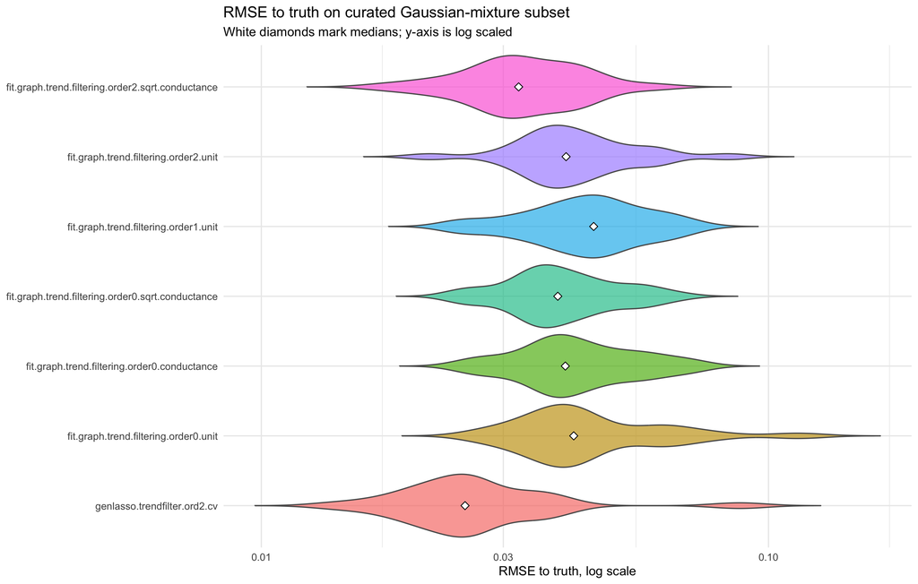

```r
ggplot(ok, aes(x = method, y = rmse.truth, fill = method)) +
  geom_violin(scale = "width", trim = FALSE, alpha = 0.65, color = "gray35") +
  stat_summary(fun = median, geom = "point", shape = 23, size = 2.3,
               fill = "white", color = "black") +
  scale_y_log10() +
  coord_flip() +
  labs(
    title = "RMSE to truth on curated Gaussian-mixture subset",
    subtitle = "White diamonds mark medians; y-axis is log scaled",
    x = NULL,
    y = "RMSE to truth, log scale"
  ) +
  theme_minimal(base_size = 11) +
  theme(legend.position = "none")
```

```r
paired_ratio <- function(dat, reference) {
  ref <- dat[dat$method == reference, c("dataset.id", "rmse.truth")]
  names(ref)[2] <- "ref.rmse"
  out <- lapply(setdiff(unique(as.character(dat$method)), reference), function(method) {
    cur <- dat[dat$method == method, c("dataset.id", "rmse.truth")]
    names(cur)[2] <- "cur.rmse"
    m <- merge(ref, cur, by = "dataset.id")
    d <- log(m$cur.rmse) - log(m$ref.rmse)
    tt <- stats::t.test(d)
    data.frame(
      method = method,
      reference = reference,
      n = length(d),
      mean.rmse.ratio = exp(mean(d)),
      ratio.conf.low = exp(unname(tt$conf.int[1])),
      ratio.conf.high = exp(unname(tt$conf.int[2])),
      median.rmse.ratio = median(m$cur.rmse / m$ref.rmse),
      p.value = tt$p.value,
      stringsAsFactors = FALSE
    )
  })
  do.call(rbind, out)
}

ratio.table <- paired_ratio(ok, "genlasso.trendfilter.ord2.cv")
ratio.table[order(ratio.table$mean.rmse.ratio), ]
```

```
##                                              method
## 6 fit.graph.trend.filtering.order2.sqrt.conductance
## 3 fit.graph.trend.filtering.order0.sqrt.conductance
## 5             fit.graph.trend.filtering.order2.unit
## 2      fit.graph.trend.filtering.order0.conductance
## 4             fit.graph.trend.filtering.order1.unit
## 1             fit.graph.trend.filtering.order0.unit
##                      reference  n mean.rmse.ratio ratio.conf.low
## 6 genlasso.trendfilter.ord2.cv 24        1.247773       1.120226
## 3 genlasso.trendfilter.ord2.cv 24        1.489014       1.356870
## 5 genlasso.trendfilter.ord2.cv 24        1.579288       1.376684
## 2 genlasso.trendfilter.ord2.cv 24        1.595453       1.446584
## 4 genlasso.trendfilter.ord2.cv 24        1.649660       1.490856
## 1 genlasso.trendfilter.ord2.cv 24        1.687658       1.487781
##   ratio.conf.high median.rmse.ratio      p.value
## 6        1.389842          1.225032 3.044828e-04
## 3        1.634027          1.506452 7.097600e-09
## 5        1.811709          1.624365 5.086970e-07
## 2        1.759642          1.600175 9.856518e-10
## 4        1.825379          1.692647 4.965375e-10
## 1        1.914388          1.657776 1.242798e-08
```

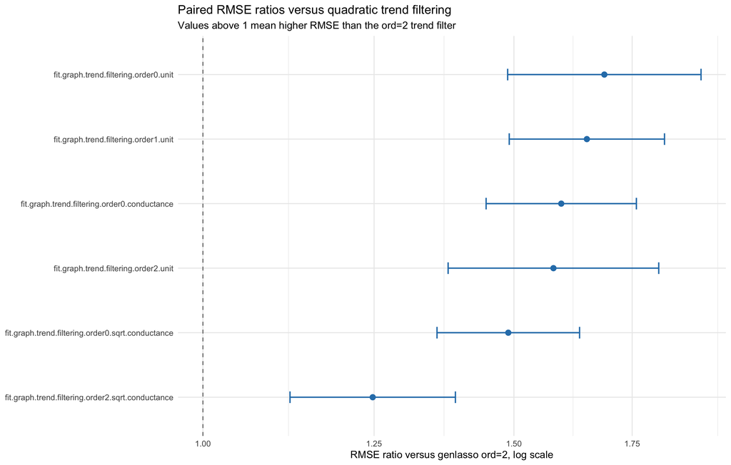

```r
ratio.plot <- ratio.table
ggplot(ratio.plot, aes(x = mean.rmse.ratio, y = reorder(method, mean.rmse.ratio))) +
  geom_vline(xintercept = 1, linetype = 2, color = "gray45") +
  geom_errorbarh(aes(xmin = ratio.conf.low, xmax = ratio.conf.high),
                 height = 0.18, linewidth = 0.7, color = "#2c7fb8") +
  geom_point(size = 2.5, color = "#2c7fb8") +
  scale_x_log10() +
  labs(
    title = "Paired RMSE ratios versus quadratic trend filtering",
    subtitle = "Values above 1 mean higher RMSE than the ord=2 trend filter",
    x = "RMSE ratio versus genlasso ord=2, log scale",
    y = NULL
  ) +
  theme_minimal(base_size = 11)
```

## 4 Example Fits

```r
predictions$method <- factor(as.character(predictions$method), levels = levels(ok$method))

dataset.order <- unique(results$dataset.id)
predictions$dataset.label <- paste0(
  predictions$dataset.id, "\n",
  predictions$shape.name, "\n",
  predictions$variant.name
)
label.levels <- unique(predictions$dataset.label[match(dataset.order, predictions$dataset.id)])
predictions$dataset.label <- factor(predictions$dataset.label, levels = label.levels)

data.points <- unique(predictions[, c("dataset.id", "dataset.label", "x", "y", "truth")])
truth.lines <- data.points[order(data.points$dataset.id, data.points$x), ]

method.colors <- c(
  "genlasso.trendfilter.ord2.cv" = "#1b9e77",
  "fit.graph.trend.filtering.order0.unit" = "#2b6cb0",
  "fit.graph.trend.filtering.order0.conductance" = "#d95f02",
  "fit.graph.trend.filtering.order0.sqrt.conductance" = "#7570b3",
  "fit.graph.trend.filtering.order1.unit" = "#66a61e",
  "fit.graph.trend.filtering.order2.unit" = "#a6761d",
  "fit.graph.trend.filtering.order2.sqrt.conductance" = "#1f78b4"
)
```

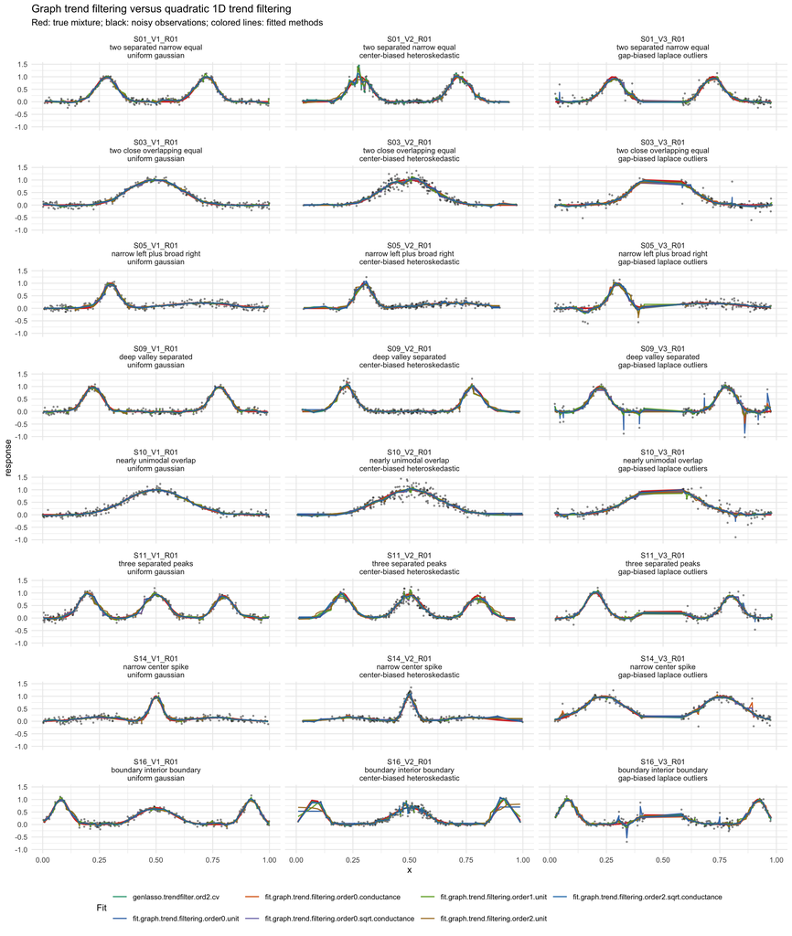

```r
ggplot() +
  geom_point(data = data.points, aes(x = x, y = y),
             color = "black", alpha = 0.38, size = 0.45) +
  geom_line(data = truth.lines, aes(x = x, y = truth),
            color = "#d73027", linewidth = 0.75) +
  geom_line(data = predictions[order(predictions$dataset.id, predictions$method, predictions$x), ],
            aes(x = x, y = fitted, color = method),
            linewidth = 0.55, alpha = 0.90) +
  facet_wrap(~ dataset.label, ncol = 3) +
  scale_color_manual(values = method.colors) +
  labs(
    title = "Graph trend filtering versus quadratic 1D trend filtering",
    subtitle = "Red: true mixture; black: noisy observations; colored lines: fitted methods",
    x = "x",
    y = "response",
    color = "Fit"
  ) +
  theme_minimal(base_size = 9) +
  theme(
    legend.position = "bottom",
    strip.text = element_text(size = 7.5)
  )
```

## 5 Where Does Graph Trend Filtering Look Best?

```r
graph.methods <- grep("^fit\\.graph\\.trend\\.filtering", as.character(ok$method), value = TRUE)
best.graph <- ok[ok$method %in% graph.methods, ]
best.graph <- best.graph[order(best.graph$dataset.id, best.graph$rmse.truth), ]
best.graph <- best.graph[!duplicated(best.graph$dataset.id), ]

ord2 <- ok[ok$method == "genlasso.trendfilter.ord2.cv", c("dataset.id", "rmse.truth")]
names(ord2)[2] <- "ord2.rmse"
best.graph <- merge(best.graph, ord2, by = "dataset.id")
best.graph$ratio.to.ord2 <- best.graph$rmse.truth / best.graph$ord2.rmse
best.graph[order(best.graph$ratio.to.ord2),
           c("dataset.id", "shape.name", "variant.name", "method",
             "rmse.truth", "ord2.rmse", "ratio.to.ord2", "lambda")]
```

```
##    dataset.id                   shape.name                  variant.name
## 2  S01_V2_R01   two separated narrow equal center-biased heteroskedastic
## 19 S14_V1_R01          narrow center spike              uniform gaussian
## 7  S05_V1_R01 narrow left plus broad right              uniform gaussian
## 10 S09_V1_R01        deep valley separated              uniform gaussian
## 12 S09_V3_R01        deep valley separated   gap-biased laplace outliers
## 18 S11_V3_R01        three separated peaks   gap-biased laplace outliers
## 17 S11_V2_R01        three separated peaks center-biased heteroskedastic
## 24 S16_V3_R01   boundary interior boundary   gap-biased laplace outliers
## 9  S05_V3_R01 narrow left plus broad right   gap-biased laplace outliers
## 3  S01_V3_R01   two separated narrow equal   gap-biased laplace outliers
## 16 S11_V1_R01        three separated peaks              uniform gaussian
## 4  S03_V1_R01  two close overlapping equal              uniform gaussian
## 22 S16_V1_R01   boundary interior boundary              uniform gaussian
## 8  S05_V2_R01 narrow left plus broad right center-biased heteroskedastic
```

[output cut: 60 more lines]

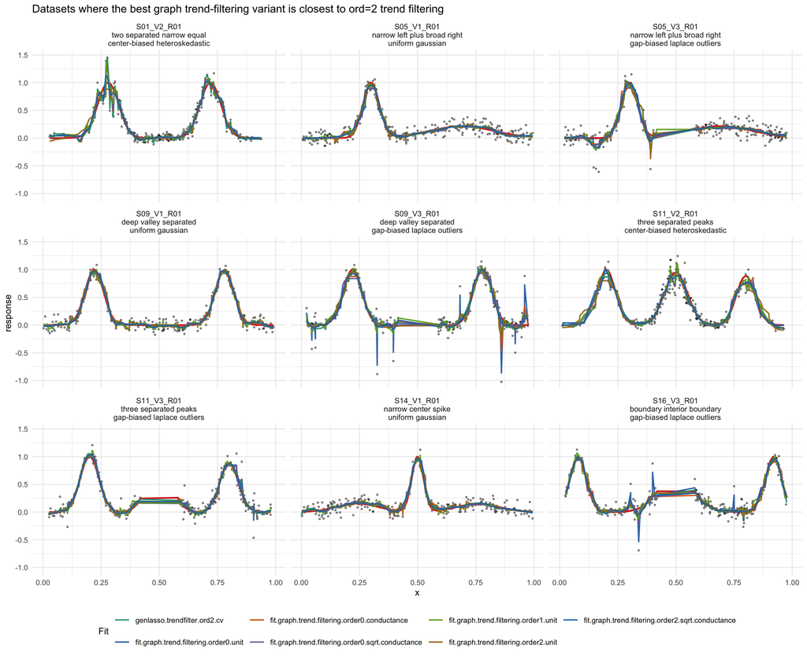

```r
top.graph.datasets <- head(best.graph$dataset.id[order(best.graph$ratio.to.ord2)], 9)
top.pred <- subset(predictions, dataset.id %in% top.graph.datasets)
top.points <- subset(data.points, dataset.id %in% top.graph.datasets)
top.truth <- subset(truth.lines, dataset.id %in% top.graph.datasets)

ggplot() +
  geom_point(data = top.points, aes(x = x, y = y),
             color = "black", alpha = 0.42, size = 0.55) +
  geom_line(data = top.truth, aes(x = x, y = truth),
            color = "#d73027", linewidth = 0.8) +
  geom_line(data = top.pred[order(top.pred$dataset.id, top.pred$method, top.pred$x), ],
            aes(x = x, y = fitted, color = method),
            linewidth = 0.65, alpha = 0.92) +
  facet_wrap(~ dataset.label, ncol = 3) +
  scale_color_manual(values = method.colors) +
  labs(
    title = "Datasets where the best graph trend-filtering variant is closest to ord=2 trend filtering",
    x = "x",
    y = "response",
    color = "Fit"
  ) +
  theme_minimal(base_size = 9) +
  theme(
    legend.position = "bottom",
    strip.text = element_text(size = 7.5)
  )
```

## 6 Interpretation

The $k=0$ graph trend-filtering fits should be read as graph fused-lasso baselines: they can create useful plateaus, but smooth Gaussian mixtures often need higher-order behavior. The $k=1$ and $k=2$ fits are the first direct graph higher-order comparators in `gflow`. If they close the gap with `genlasso::trendfilter(..., ord = 2)`, that supports continuing with solver and weighting refinements. If they remain worse but visually sensible, the likely next issue is not the operator definition alone but the solver, path-graph boundary behavior, and metric weighting convention.